# A3_Pollock_20151606

Caleb Pollock

2023-01-25

#Libraries and Data

```r
library(ggplot2)
library(MASS)
library(dplyr)
library(tidyr)

lythDat <- read.csv("https://colauttilab.github.io/Data/ColauttiBarrett2013Data.csv",header=TRUE)

source("https://bit.ly/theme_pub")

theme_set(theme_pub())
```

# Data Inspection

```r
#Basic data inspection functions to get a initial look
str(lythDat)
```

```
## 'data.frame':    432 obs. of  23 variables:
##  $ Ind      : int  1 2 3 4 5 6 7 8 9 10 ...
##  $ Site     : chr  "1_BEF" "1_BEF" "1_BEF" "1_BEF" ...
##  $ Row      : int  1 1 1 1 1 1 1 1 1 1 ...
##  $ Pos      : int  1 2 3 4 5 6 7 8 9 10 ...
##  $ Mat      : chr  "C13" "C11" "A16" "C20" ...
##  $ Pop      : chr  "C" "C" "A" "C" ...
##  $ Region   : chr  "NORTH" "NORTH" "NORTH" "NORTH" ...
##  $ Flwr07   : int  39285 39293 39286 39305 39293 39291 39287 39293 39287 39303 ...
##  $ FVeg07   : num  41 40 32.5 45 47.5 55 51.5 38 51 37.5 ...
##  $ InfMass07: num  9.7 6.5 16 1.5 17.4 13.1 3 0.6 0 12.2 ...
##  $ Fruits07 : int  625 329 1029 46 1121 504 122 15 0 896 ...
##  $ Flwr08   : int  39613 39625 39610 39638 39616 39625 39614 39621 39617 39638 ...
##  $ FVeg08   : num  79 117 70 94.5 97 ...
##  $ HVeg08   : num  71 108 62.5 87.5 90 124 85 76.5 91 96.5 ...
##  $ InfMass08: num  9.7 36.1 28.9 18.2 47.9 30.7 23.3 8.5 28.5 16.6 ...
##  $ Flwr09   : int  39980 39993 NA 40000 39986 39995 39990 39993 39996 39997 ...
##  $ FVeg09   : num  64 70 NA 84 66 91 80 62 58 99 ...
##  $ HVeg09   : num  82 65.5 NA 72 65.5 82 76 60.5 56.5 93.5 ...
##  $ InfMass09: num  11.7 10.1 NA 9.6 38.1 16.7 11.1 2.6 1.7 18.8 ...
##  $ Flwr10   : int  40345 40350 NA 40369 40353 40357 40350 NA 40358 40357 ...
##  $ FVeg10   : num  68.7 83.4 NA 69.9 70.1 97 105 NA 50.8 85.1 ...
##  $ HVeg10   : num  66 96 NA 57.5 65.5 77 98 57 49.5 82 ...
##  $ InfMass10: num  1.9 7.3 NA 5.7 27.9 4.9 5.3 5.5 1.5 15.3 ...
```

```r
head(lythDat)
```

```
##   Ind  Site Row Pos Mat Pop Region Flwr07 FVeg07 InfMass07 Fruits07 Flwr08
## 1   1 1_BEF   1   1 C13   C  NORTH  39285   41.0       9.7      625  39613
## 2   2 1_BEF   1   2 C11   C  NORTH  39293   40.0       6.5      329  39625
## 3   3 1_BEF   1   3 A16   A  NORTH  39286   32.5      16.0     1029  39610
## 4   4 1_BEF   1   4 C20   C  NORTH  39305   45.0       1.5       46  39638
## 5   5 1_BEF   1   5  T3   T  SOUTH  39293   47.5      17.4     1121  39616
## 6   6 1_BEF   1   6 C18   C  NORTH  39291   55.0      13.1      504  39625
##   FVeg08 HVeg08 InfMass08 Flwr09 FVeg09 HVeg09 InfMass09 Flwr10 FVeg10 HVeg10
## 1   79.0   71.0       9.7  39980     64   82.0      11.7  40345   68.7   66.0
## 2  117.0  108.0      36.1  39993     70   65.5      10.1  40350   83.4   96.0
## 3   70.0   62.5      28.9     NA     NA     NA        NA     NA     NA     NA
## 4   94.5   87.5      18.2  40000     84   72.0       9.6  40369   69.9   57.5
## 5   97.0   90.0      47.9  39986     66   65.5      38.1  40353   70.1   65.5
## 6  128.5  124.0      30.7  39995     91   82.0      16.7  40357   97.0   77.0
##   InfMass10
## 1       1.9
## 2       7.3
## 3        NA
## 4       5.7
## 5      27.9
## 6       4.9
```

```r
#Seperating Data sets
Flwr <- lythDat %>% # Data set for the Flwr variable
  dplyr::select(starts_with("Flwr"))

Flwr <- Flwr %>% # Fix NA in Flwr
  mutate(Flwr07 = ifelse(is.na(Flwr07),
                         mean(Flwr07,na.rm=T),Flwr07),
         Flwr08 = ifelse(is.na(Flwr08),
                         mean(Flwr08,na.rm=T),Flwr08),
         Flwr09 = ifelse(is.na(Flwr09),
                         mean(Flwr09,na.rm=T),Flwr09),
         Flwr10 = ifelse(is.na(Flwr10),
                         mean(Flwr10,na.rm=T),Flwr10))

FVeg <- lythDat %>% # Data set for the FVeg variable
  dplyr::select(starts_with("FVeg"))

FVeg <- FVeg %>% # Fix NA in FVeg
  mutate(FVeg07 = ifelse(is.na(FVeg07),
                         mean(FVeg07,na.rm=T),FVeg07),
         FVeg08 = ifelse(is.na(FVeg08),
                         mean(FVeg08,na.rm=T),FVeg08),
         FVeg09 = ifelse(is.na(FVeg09),
                         mean(FVeg09,na.rm=T),FVeg09),
         FVeg10 = ifelse(is.na(FVeg10),
                         mean(FVeg10,na.rm=T),FVeg10))

InfMass <- lythDat %>% # Data set for the InfMass variable
  dplyr::select(starts_with("InfMass"))


InfMass <- InfMass %>% # Fix NA in InfMass
  mutate(InfMass07 = ifelse(is.na(InfMass07),
                            mean(InfMass07,na.rm=T),InfMass07),
         InfMass08 = ifelse(is.na(InfMass08),
                            mean(InfMass08, na.rm = T), InfMass08),
         InfMass09 = ifelse(is.na(InfMass09),
                            mean(InfMass09, na.rm = T),InfMass09),
         InfMass10 = ifelse(is.na(InfMass10),
                            mean(InfMass10, na.rm = T),InfMass10))
```

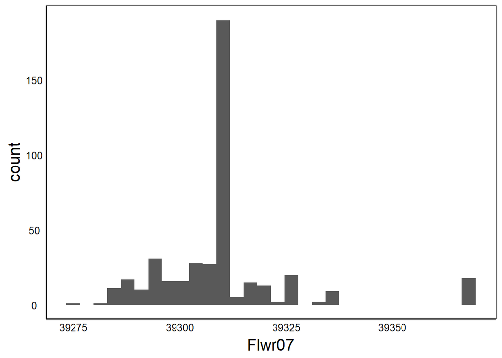

```r
# creating some histograms for checking normality for Flwr

ggplot(aes(x=Flwr07),data=Flwr) +
  geom_histogram()
```

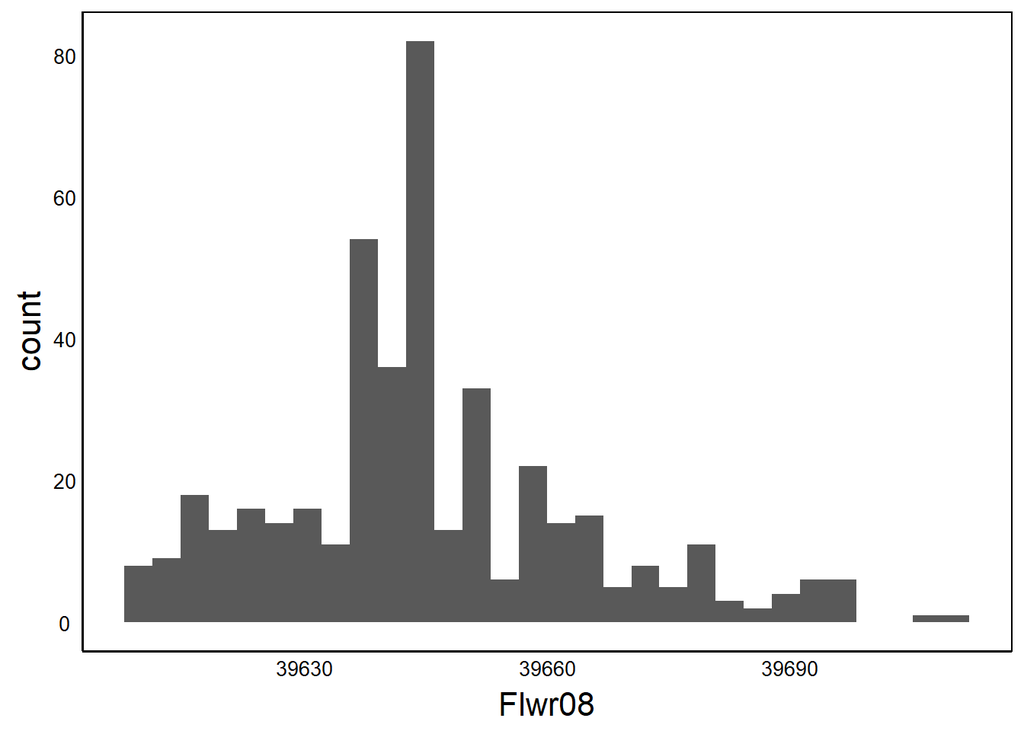

```r
ggplot(aes(x=Flwr08),data=Flwr) +
  geom_histogram()
```

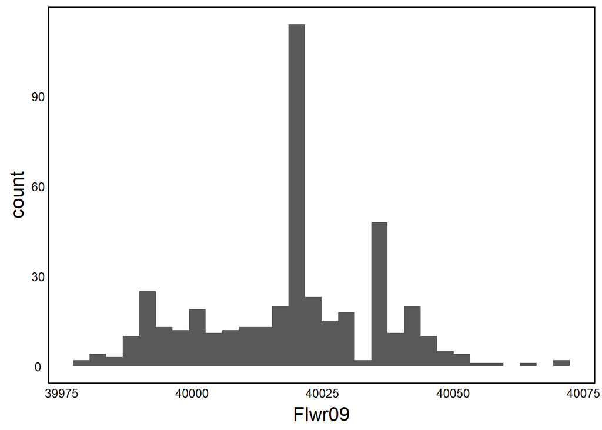

```r
ggplot(aes(x=Flwr09),data=Flwr) +
  geom_histogram()
```

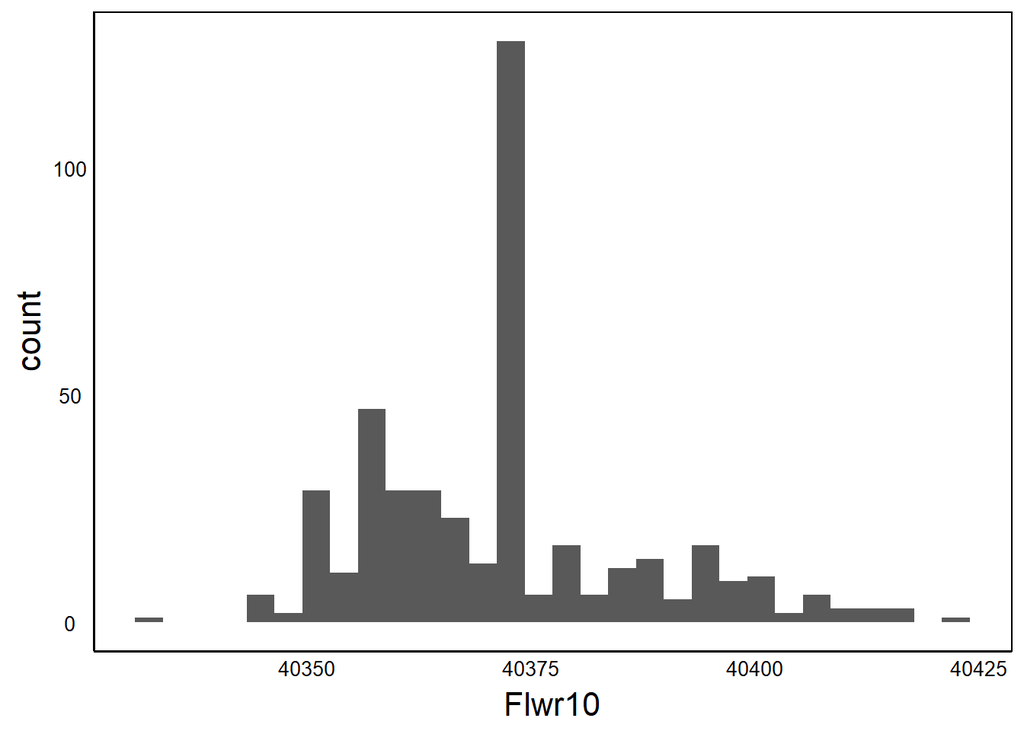

```r
ggplot(aes(x=Flwr10),data=Flwr) +
  geom_histogram()
```

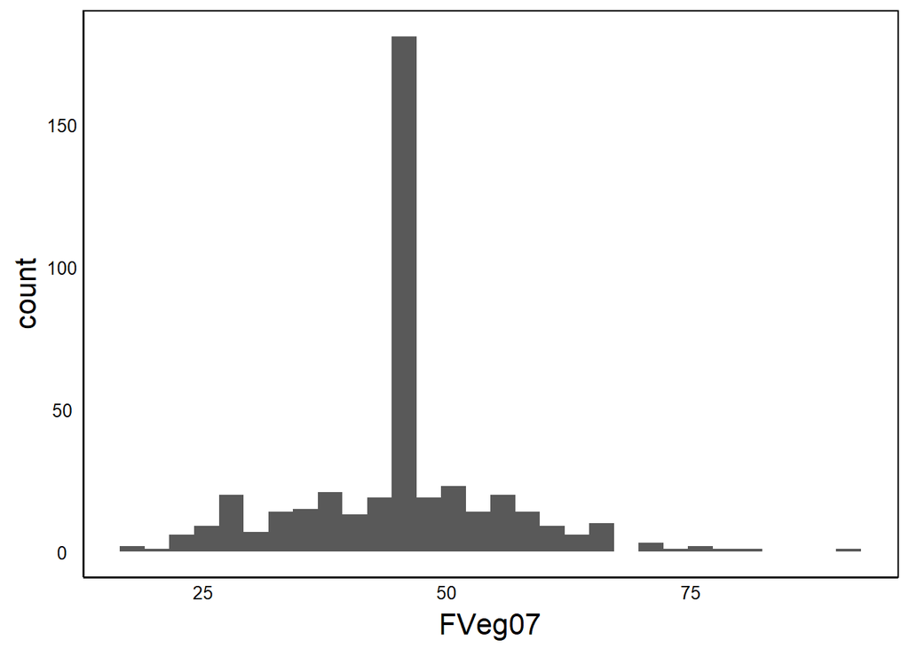

```r
# creating some histograms for checking normality for FVeg

ggplot(aes(x=FVeg07),data=FVeg) +
  geom_histogram()
```

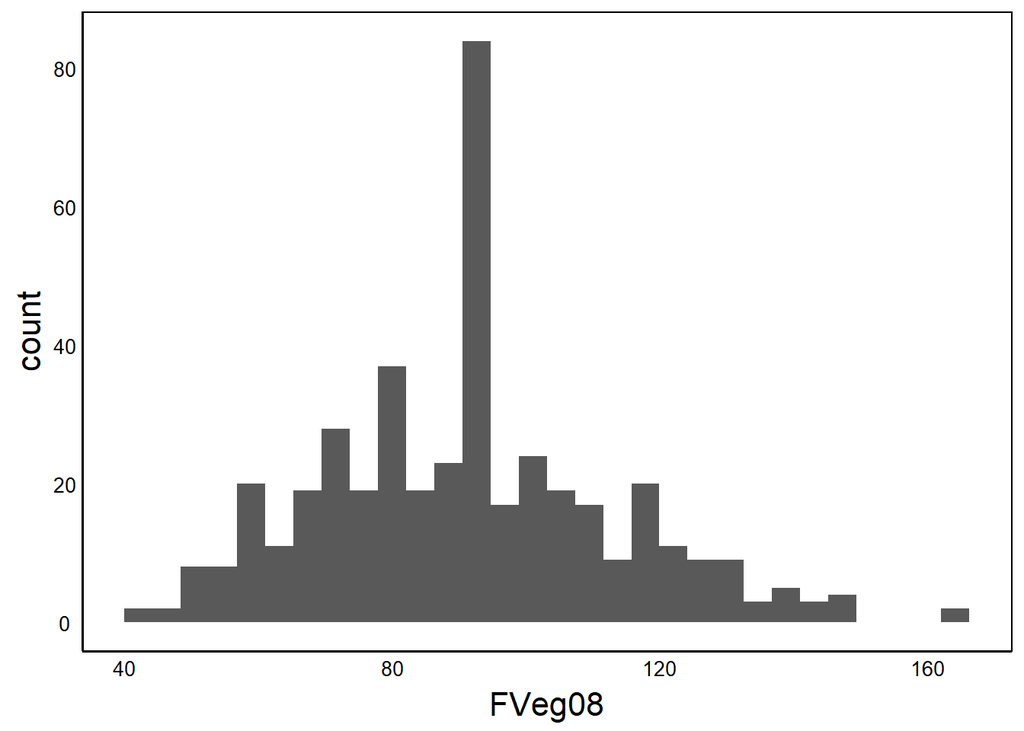

```r
ggplot(aes(x=FVeg08),data=FVeg) +
  geom_histogram()
```

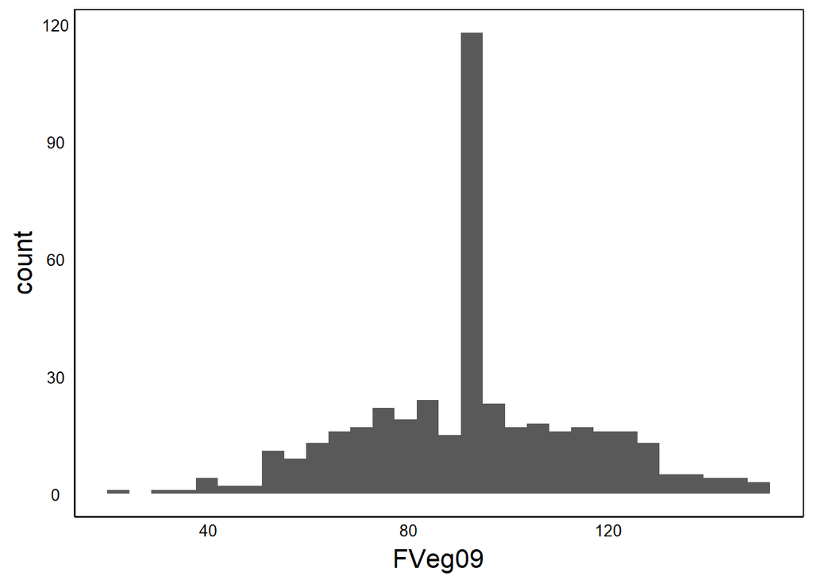

```r
ggplot(aes(x=FVeg09),data=FVeg) +
  geom_histogram()
```

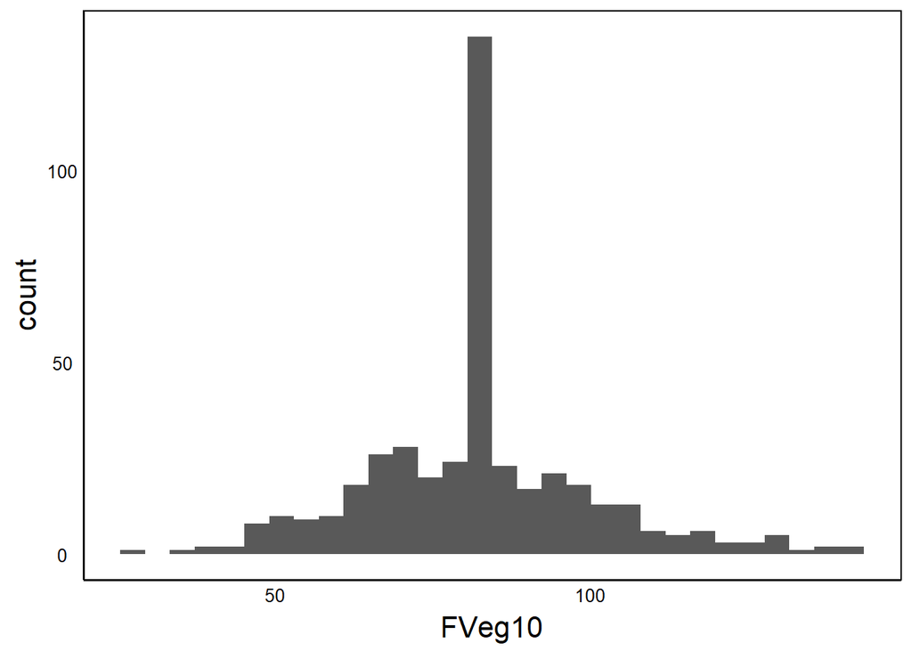

```r
ggplot(aes(x=FVeg10),data=FVeg) +
  geom_histogram()
```

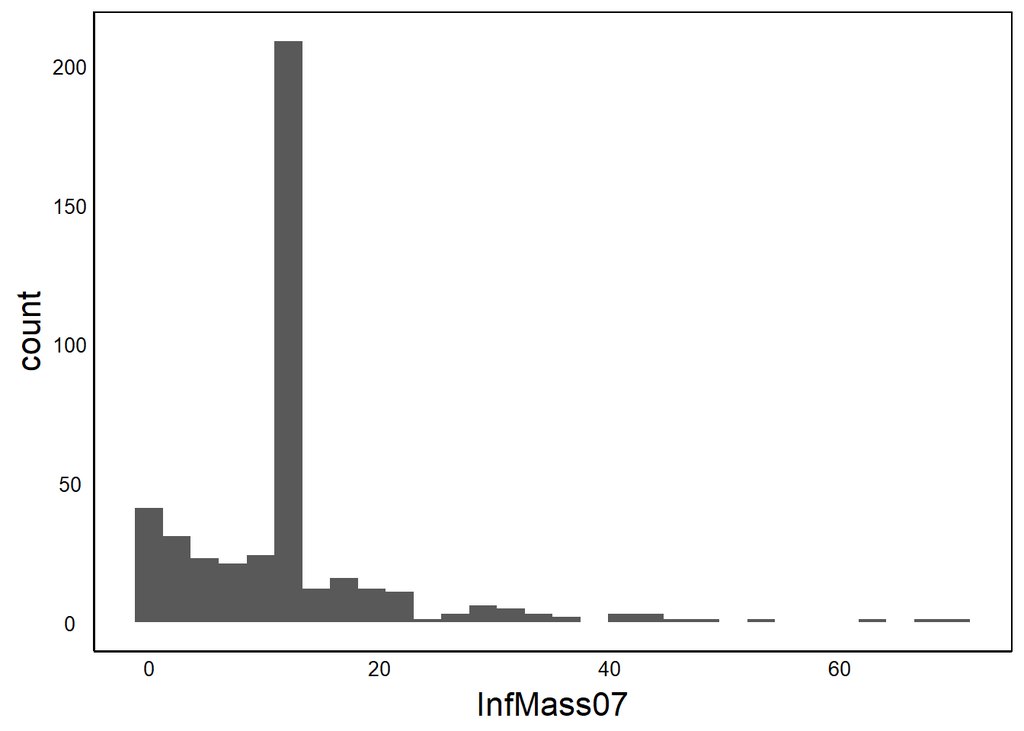

```r
# creating some histograms for checking normality for InfMass

ggplot(aes(x=InfMass07),data=InfMass) +
  geom_histogram()
```

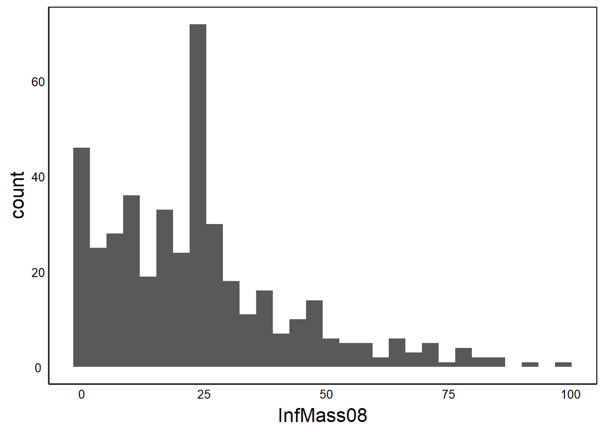

```r
ggplot(aes(x=InfMass08),data=InfMass) +
  geom_histogram()
```

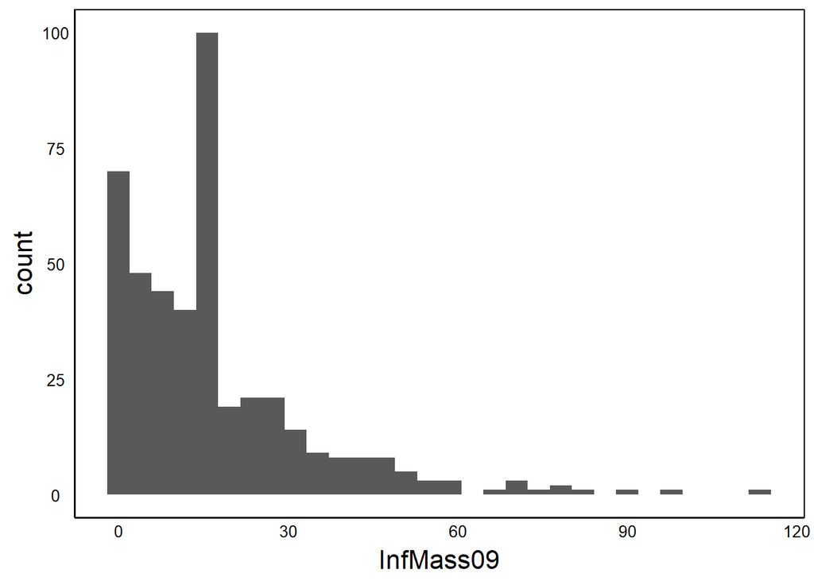

```r
ggplot(aes(x=InfMass09),data=InfMass) +
  geom_histogram()
```

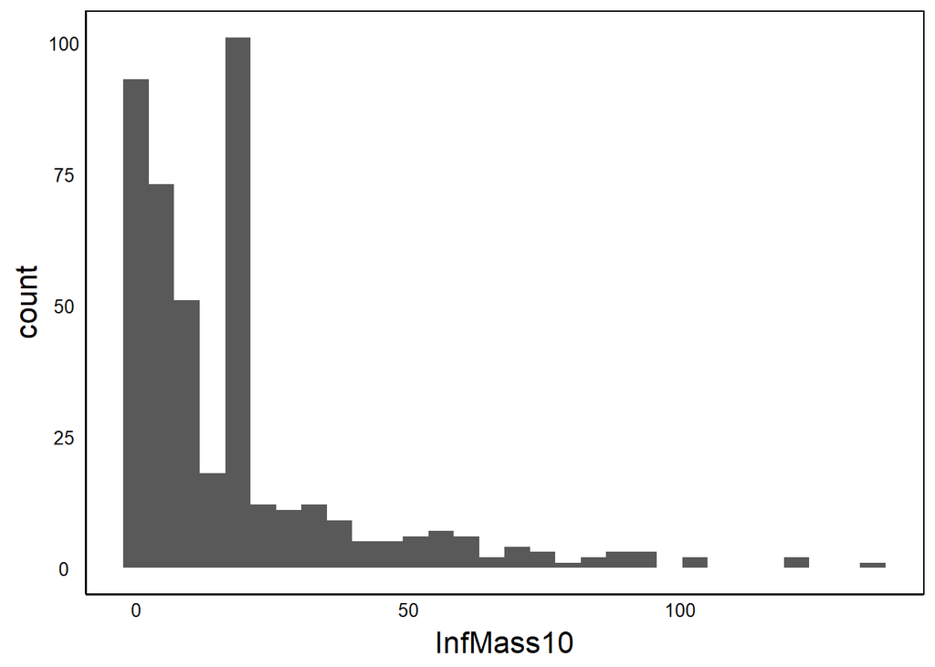

```r
ggplot(aes(x=InfMass10),data=InfMass) +
  geom_histogram()
```

# Scaling and Creating Features and Classifying Data sets

```r
# Creating the features Data set and scaling them
Features <- cbind(Flwr,FVeg, InfMass)
head(Features)
```

```
##   Flwr07 Flwr08   Flwr09   Flwr10 FVeg07 FVeg08   FVeg09   FVeg10 InfMass07
## 1  39285  39613 39980.00 40345.00   41.0   79.0 64.00000 68.70000       9.7
## 2  39293  39625 39993.00 40350.00   40.0  117.0 70.00000 83.40000       6.5
## 3  39286  39610 40018.79 40371.37   32.5   70.0 92.86578 82.28812      16.0
## 4  39305  39638 40000.00 40369.00   45.0   94.5 84.00000 69.90000       1.5
## 5  39293  39616 39986.00 40353.00   47.5   97.0 66.00000 70.10000      17.4
## 6  39291  39625 39995.00 40357.00   55.0  128.5 91.00000 97.00000      13.1
##   InfMass08 InfMass09 InfMass10
## 1       9.7  11.70000   1.90000
## 2      36.1  10.10000   7.30000
## 3      28.9  17.13445  18.05809
## 4      18.2   9.60000   5.70000
## 5      47.9  38.10000  27.90000
## 6      30.7  16.70000   4.90000
```

```r
#Creating the classifying data set using site and pop as the classifiers
RespDat <- lythDat %>%
  dplyr::select(2,6)
head(RespDat)
```

```
##    Site Pop
## 1 1_BEF   C
## 2 1_BEF   C
## 3 1_BEF   A
## 4 1_BEF   C
## 5 1_BEF   T
## 6 1_BEF   C
```

```r
# Creating the scaled features data set using the method in the Discriminant Analysis tutorial
ScaledFeat <- Features %>%
  mutate_all(scale)
head(ScaledFeat)
```

```
##       Flwr07     Flwr08    Flwr09     Flwr10      FVeg07     FVeg08      FVeg09
## 1 -1.5342273 -1.7054864 -2.316848 -1.7335018 -0.42263939 -0.5475247 -1.29842912
## 2 -1.0366657 -1.0710074 -1.540286 -1.4047590 -0.52084916  1.1918177 -1.02853951
## 3 -1.4720321 -1.8641061  0.000000  0.0000000 -1.25742246 -0.9594742  0.00000000
## 4 -0.2903234 -0.3836552 -1.122137 -0.1555364 -0.02980029  0.1619439 -0.39879707
## 5 -1.0366657 -1.5468667 -1.958435 -1.2075133  0.21572414  0.2763743 -1.20846592
## 6 -1.1610561 -1.0710074 -1.420815 -0.9445191  0.95229744  1.7181976 -0.08392585
##        FVeg10  InfMass07  InfMass08   InfMass09  InfMass10
## 1 -0.75959489 -0.2508060 -0.7300036 -0.32595382 -0.7387134
## 2  0.06215534 -0.5894649  0.6513790 -0.42192043 -0.4918370
## 3  0.00000000  0.4159287  0.2746383  0.00000000  0.0000000
## 4 -0.69251324 -1.1186194 -0.2852403 -0.45190999 -0.5649855
## 5 -0.68133296  0.5640920  1.2688151  1.25749525  0.4499510
## 6  0.82241406  0.1090191  0.3688234 -0.02605816 -0.6015598
```

# Feature Selection and Why it’s Not Necessary

In the case of this data set, it is not neccesary to preform feature selection. Feature selection is preformed to determine which features maintain good predictive power at distinguishing among groups. In the PCA tutorial, we were analyzing a data set comparing 14 chemicals and determining how there ability to distinguish a patients COVID status. In the case of lythrum data, our data set only covers 3 traits over 4 years, meaning that the data set already contains a small number of features, and eliminating some features may limit the scope of the analysis.

# LDA

To run LDAs distinguishing between genetic populations and regions, we will use the lda() function in MASS with our classifying/response variable being either pop or site. The features will be InfMass, FVeg, and Flwr.

```r
# Run LDA

SiteMod <- lda(x=ScaledFeat, grouping = RespDat$Site) # Site model
summary(SiteMod) # summary of mod
```

```
##         Length Class  Mode
## prior    3     -none- numeric
## counts   3     -none- numeric
## means   36     -none- numeric
## scaling 24     -none- numeric
## lev      3     -none- character
## svd      2     -none- numeric
## N        1     -none- numeric
## call     3     -none- call
```

```r
str(SiteMod) # structure of mod
```

```
## List of 8
##  $ prior  : Named num [1:3] 0.312 0.347 0.34
##   ..- attr(*, "names")= chr [1:3] "1_BEF" "2_KSR" "3_Timmins"
##  $ counts : Named int [1:3] 135 150 147
##   ..- attr(*, "names")= chr [1:3] "1_BEF" "2_KSR" "3_Timmins"
##  $ means  : num [1:3, 1:12] -0.7719 0.2594 0.4442 -0.9576 0.0646 ...
##   ..- attr(*, "dimnames")=List of 2
##   .. ..$ : chr [1:3] "1_BEF" "2_KSR" "3_Timmins"
##   .. ..$ : chr [1:12] "Flwr07" "Flwr08" "Flwr09" "Flwr10" ...
##  $ scaling: num [1:12, 1:2] 0.373 1.221 0.483 0.209 -0.307 ...
##   ..- attr(*, "dimnames")=List of 2
##   .. ..$ : chr [1:12] "Flwr07" "Flwr08" "Flwr09" "Flwr10" ...
##   .. ..$ : chr [1:2] "LD1" "LD2"
##  $ lev    : chr [1:3] "1_BEF" "2_KSR" "3_Timmins"
##  $ svd    : num [1:2] 22.8 13.4
##  $ N      : int 432
##  $ call   : language lda(x = ScaledFeat, grouping = RespDat$Site)
##  - attr(*, "class")= chr "lda"
```

```r
PopMod <- lda(x=ScaledFeat, grouping = RespDat$Pop) # Pop model
summary(PopMod) # summary of mod
```

```
##         Length Class  Mode
## prior    6     -none- numeric
## counts   6     -none- numeric
## means   72     -none- numeric
## scaling 60     -none- numeric
## lev      6     -none- character
## svd      5     -none- numeric
## N        1     -none- numeric
## call     3     -none- call
```

```r
str(PopMod) # structure of mod
```

```
## List of 8
##  $ prior  : Named num [1:6] 0.104 0.199 0.199 0.19 0.185 ...
##   ..- attr(*, "names")= chr [1:6] "A" "C" "E" "J" ...
##  $ counts : Named int [1:6] 45 86 86 82 80 53
##   ..- attr(*, "names")= chr [1:6] "A" "C" "E" "J" ...
##  $ means  : num [1:6, 1:12] -0.22626 0.13952 -0.18254 0.00121 0.09248 ...
##   ..- attr(*, "dimnames")=List of 2
##   .. ..$ : chr [1:6] "A" "C" "E" "J" ...
##   .. ..$ : chr [1:12] "Flwr07" "Flwr08" "Flwr09" "Flwr10" ...
##  $ scaling: num [1:12, 1:5] -0.1083 0.2314 -0.2494 -0.0682 0.3743 ...
##   ..- attr(*, "dimnames")=List of 2
##   .. ..$ : chr [1:12] "Flwr07" "Flwr08" "Flwr09" "Flwr10" ...
##   .. ..$ : chr [1:5] "LD1" "LD2" "LD3" "LD4" ...
##  $ lev    : chr [1:6] "A" "C" "E" "J" ...
##  $ svd    : num [1:5] 10.67 4.28 3.08 1.86 1.42
##  $ N      : int 432
##  $ call   : language lda(x = ScaledFeat, grouping = RespDat$Pop)
##  - attr(*, "class")= chr "lda"
```

# LD Axes

# LD Objects

The $scaling slice show the factor loadings, which are also known as the LD eigenvectors.This is the method that allows comparison from the Model to the original dataset. This relates to the LD eigenvectors because they are the LD eigenvectors. Eigenvectors for linear discriminant analysis differ from those of principle components analysis in that LD loadings are calculated to distinguish between groups, where PC loadings are meant to explain variation across all of the features included in the analysis. Thus, LDA is best used for disntinguishing groups.

# Predict

```r
SitePred <- predict(SiteMod) # Calculating scores for Site
summary(SitePred)
```

```
##           Length Class  Mode
## class      432   factor numeric
## posterior 1296   -none- numeric
## x          864   -none- numeric
```

```r
PopPred <- predict(PopMod) # Calculating scores for Pop
summary(PopPred)
```

```
##           Length Class  Mode
## class      432   factor numeric
## posterior 2592   -none- numeric
## x         2160   -none- numeric
```

# LDA Models and Lythrum Data

```r
# Viewing LD
SiteMod$scaling
```

```
##                   LD1         LD2
## Flwr07     0.37320699 -0.14337332
## Flwr08     1.22062353 -0.43176370
## Flwr09     0.48250005 -0.16246347
## Flwr10     0.20898645  0.87227009
## FVeg07    -0.30702072  0.09042961
## FVeg08    -0.45696056  1.02022666
## FVeg09     0.06576584 -0.33149313
## FVeg10    -0.18962879 -0.77689935
## InfMass07  0.13189615  0.41038906
## InfMass08  0.49019658 -0.70937290
## InfMass09 -0.08826171  0.18864159
## InfMass10 -0.22662727 -0.23932409
```

```r
PopMod$scaling
```

```
##                   LD1         LD2           LD3        LD4          LD5
## Flwr07    -0.10828281 -0.11999710 -0.3394718382  0.1129802  0.326096168
## Flwr08     0.23138687  0.77006987 -0.1669482715  0.2399192 -0.472336244
## Flwr09    -0.24936931 -0.32999086  0.5235816178  1.0488103  0.819757997
## Flwr10    -0.06824047 -0.06062291 -0.0957690715 -0.9323343 -0.091423809
## FVeg07     0.37428239  0.37985947  0.1062694427  0.4694927 -0.787761353
## FVeg08     0.56276955 -0.73591105  0.0294356333  0.2665493  1.033565121
## FVeg09     0.34733322  0.07148214  0.1803803074 -0.9022544 -0.134770874
## FVeg10     0.39393255 -0.10624250 -0.7680018814  0.2799493 -0.627830313
## InfMass07  0.31736510  0.10093947 -0.0016410233 -0.6384281  0.266905950
## InfMass08 -0.41559917 -0.76161240 -0.2405871620  0.1493713 -0.396025421
## InfMass09  0.08208306 -0.33211758  1.1895082710  0.3901902  0.006757304
## InfMass10  0.16895129  0.82825129  0.0006808059 -0.0470864  0.575218156
```

From analyzing the Lythrum Data through LDA models, it is observed that FVeg07-FVeg10 are the traits that best describe LD1 in the population model, and that Flwr07-Flwr10 are the traits that best describe LD1 in the site model. In the Population model LD2 is primarily described by InfMass10 and Flwr08, and in LD2 of the site model FVeg08 and Flwr10 distiguishes the best. For LD3 in population InfMass09 and Flwr09 distinguish the highest. In LD4 Flwr09 is the highest, and in LD5 FVeg08 and Flwr09 distinguish between groups the best.

When comparing these results to the PCA tutorial, PC1 was affected by all three measurements, and PC2 was primarily differentiated by InfMass and Flwr.

In the Population model, the trait of FVeg distinguishes the best, whereas in the site model, Flwr distinguishes the best.

Height of the vegatative component of the plant may explain the ability to distinguish between populations due to height being a genetic factor. All indivduals of the “A” population share a genetic lineage, meaning that they would have closer height to a member of population “A” than a member of population “C”, “E”, “J”, “T”. This would result in the model being able to group those of similar height together easier. Contrasting this to Julian day of first flower (Flwr) distinguishing between sites the best, although this trait may be genetic, it is likely much more connected to environmental components such as sunlight, temperature, availability of resources etc. The three different sites will all experience different temperatures, sunlight, weather conditions, and those populations will be more similar to themselves than populations at the other sites. Thus, Flwr will be able to distinguish sites better than the other measurements.